# Hotel price predictions in Vienna

Julianna Szabo

2/11/2021

For this project, the aim was to predict prices of hotels in Vienna for a certain night and then find the best deals based on the prediction. THe data set used was the hotels_vienna set from Chapter 10 of the book “Data Analytics for Business, Economics, and Politics” by Gabor Bekes and Gabor Kezdi. While their analysis focused on multiple linear regression, in this project both linear and machine learning methods will be applied to this problem to see their comperative performances.

# Sample desing

To make this project realistic, the data set was filtered down to a single weekday in November 2017. This is crucial since the prices of hotel rooms vary between months or even weeks, and weekdays differ greatly from weekends or holiday.

# Label engineering

The dependent variable in this analysis will be price. The price in this analysis is given in Euros (the local currency). Looking at the distribution of the price it can be seen that there are some extreme values over 500. These are most likely very high end luxury hotels and not part of the average hotel offering. Since these values could distort our model for the more common price as well as these not being of interesting to the vast majority of people looking for hotels in Vienna, they have been excluded. After the limitation of the price, the graph has a much better almost normal distribution.

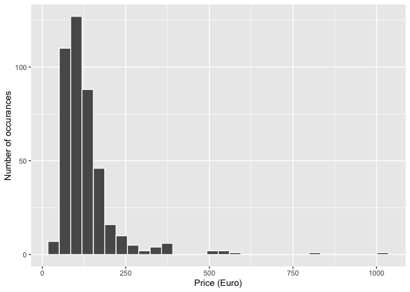

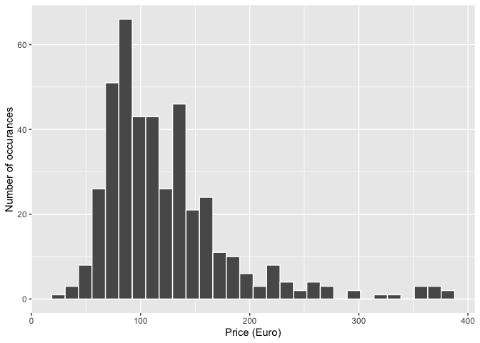

# Feature engineering

Overall the data set it already very clean, however, some changes has to be made so that the data is feasable for this analysis. Facotr variables were created for “accommodation type”, “offer cateogiry”, and “neighbourhood”. These variables included some categories that were very infrequent which have been either combined with other variables, in the case of “offer category”, or replaces by “other” in the two other variables. Further flags were created for closeness to city center for hotels that are located closer than 1 km since this was shown to have a significant impact on the price. Lastly, the many missing values in the different “rating” columns were replaced by zeros and flags created to note the replacement.

# Explanatory variable selection

Overall the explanatory variables in the data were few, so it was important to check for correlation within them to not harm out mode. Looking at the correlation table, it can be seen that only variables that are based on each other have a strong correlation. The only exception are the two “rating” variables, which show that both Trip Advisor and the price comparison website have similar ratings for a property, which is good and shows consistency.

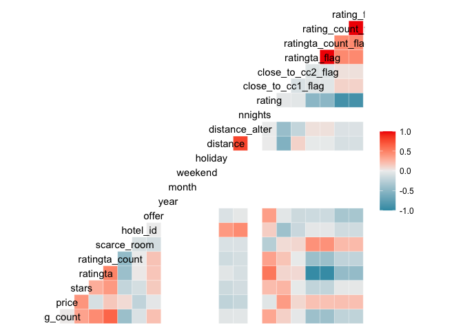

# Model building

After checking the correlation, the exploratory variables were grouped into different cateogires to simplify model building. Five categories were created: basics, distance, rating, offer, and hotel related information. These groups were combined to create five more and more complex models. Further, variables for a LASSO model were created which included two groupw of interactions (numeric and non-numeric) to increase the number of variables to as high as possible for LASSO to narrow them down.

Also a holdout / test set was created with 20% of the observations. This was first debated, since there are only around 400 observations, however, since not all models have the option of cross-validation this was the easiest method to compare the different final results.